# MachineLearning

One thing that people regularly do is quantify how much of a particular activity they do, but they rarely quantify how well they do it. The goal of this project is to predict the manner in which they did the exercise.

## Loading the provided training dataset

```r
pml<- read.csv("~/Downloads/pml-training.csv", na.strings=c("NA","","#DIV/0!"))
```

## Pre-Processing

Removing any colum that has an NA value and keeping only the completed pml dataset

```r
isNA<- apply(pml,2,function(x){sum(is.na(x))})
completePml<- pml[,isNA==0]
```

Now removing any columns that are not directly related to the classe outcome.

```r
finalPml<- completePml[,-c(1:7)]
```

Creating the “Training” and “Validation” datasets.

```r
set.seed(312)
inTrain<- createDataPartition(finalPml$classe, p = 0.7, list = FALSE)
train<- finalPml[inTrain,]
validation<- finalPml[-inTrain,]
```

Removing zero covariates

```r
nsv<- nearZeroVar(train, saveMetrics = TRUE)
nsv[nsv$nzv==TRUE,]
```

```
## [1] freqRatio     percentUnique zeroVar       nzv
## <0 rows> (or 0-length row.names)
```

Since no rows were returned we cannot assume that a particular variable is not important to the analysis.

## Analysis with Regression Tree

First we fit a tree to this data and summarize it

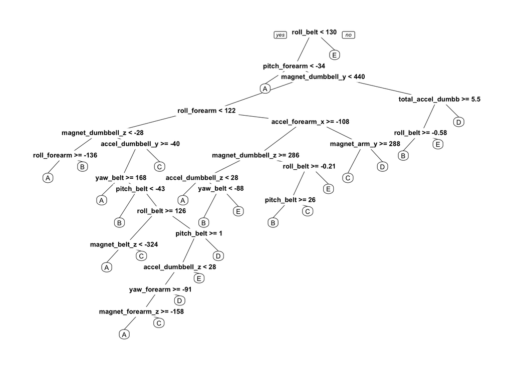

```r
set.seed(312)
fit<- rpart(classe~., data=train)
prp(fit)
```

### Cross Validation with the regression tree on Validation dataset

We are checking the performance of the regression tree.

```r
tree.pred<- predict(fit, newdata= validation, type = "class")
tablePred<- table(validation$classe, tree.pred)
sum(diag(tablePred))/sum(as.vector(tablePred))
```

```
## [1] 0.759898
```

Thus we get a prediction accuracy of ~76% and an out of sample error rate as ~24% for this regression tree

## Analysis with Random Forests

Here we will fit a Random forest to help increase the model accuracy and reduce out of sample error.

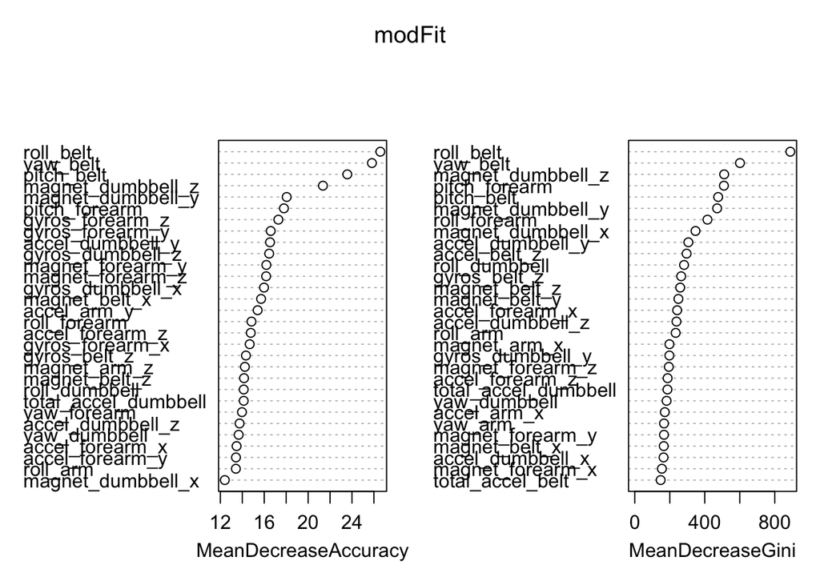

```r
set.seed(312)
modFit<- randomForest(classe~., data=train, ntree = 100, importance = TRUE)
varImpPlot(modFit)
```

### Cross Validation with the Random Forest on Validation dataset

Here we are checking the performance of the Random Forest

```r
rf.pred<- predict(modFit, newdata= validation, type="class")
predTable<- table(validation$classe, rf.pred)
sum(diag(predTable))/sum(as.vector(predTable))
```

```
## [1] 0.9945624
```

Thus we get a prediction accuracy of ~99.4% and an out of sample error of ~0.6%

## Making Predictions

In conclusion, we can now predict values of classe for the original testing data set provided for the assignment.

```r
pml_testing<- read.csv("~/Downloads/pml-testing.csv")
predict(modFit, pml_testing, type = "class")
```

```
##  1  2  3  4  5  6  7  8  9 10 11 12 13 14 15 16 17 18 19 20
##  B  A  B  A  A  E  D  B  A  A  B  C  B  A  E  E  A  B  B  B
## Levels: A B C D E
```

These are the answers for the coursera assignment.

We can observe that the random forest is very good in making these kinds of predictions as we can see from the out of sample erroe at around 0.6%